# Lab12

Katherine Filpo

4/15/2020

## Part 1

### Question 1

ROT~OXYGEN, TEMP, BAC, or the interactions between any of those.

**Hypotheses**

H<sub>01</sub> There is no effect of the intereaction between oxygen, temperature and bacteria on the rate of rot of the potatoes.

H<sub>02</sub> There is no effect of the interation between oxygen and the temperature.

H<sub>03</sub> There is no effect of the interaction between oxygen and bacteria.

H<sub>04</sub> There is no effect of the interaction between temperature and bacteria.

H<sub>05</sub> There is no effect of the oxygen.

H<sub>06</sub> There is no effect of the temperature.

H<sub>07</sub> There is no effect of the bacteria.

```r
model_1 <-lm(ROT~factor(BAC)*factor(TEMP)*factor(OXYGEN), data = potatoes)
anova(model_1)
```

```
## Analysis of Variance Table
##
## Response: ROT
##                                         Df Sum Sq Mean Sq F value    Pr(>F)
## factor(BAC)                              2 651.81  325.91 13.9123 3.339e-05 ***
## factor(TEMP)                             1 848.07  848.07 36.2024 6.599e-07 ***
## factor(OXYGEN)                           2  97.81   48.91  2.0877   0.13872
## factor(BAC):factor(TEMP)                 2 152.93   76.46  3.2640   0.04981 *
## factor(BAC):factor(OXYGEN)               4  30.07    7.52  0.3209   0.86207
## factor(TEMP):factor(OXYGEN)              2   1.59    0.80  0.0340   0.96661
## factor(BAC):factor(TEMP):factor(OXYGEN)  4  81.41   20.35  0.8688   0.49206
## Residuals                               36 843.33   23.43
## ---
## Signif. codes:  0 '***' 0.001 '**' 0.01 '*' 0.05 '.' 0.1 ' ' 1
```

**Conclusion:** H<sub>04</sub> must be rejected as the **P** = 0.0498. H<sub>06</sub> must be rejected as the **P** < 0.0001. H<sub>07</sub> must be rejected as the **P** < 0.0001. H<sub>01,2,3,5</sub> are suppported.

### Question 2

The assumumptions of normality and the homogeneity of varience are respected in the analysis used to make model 1.

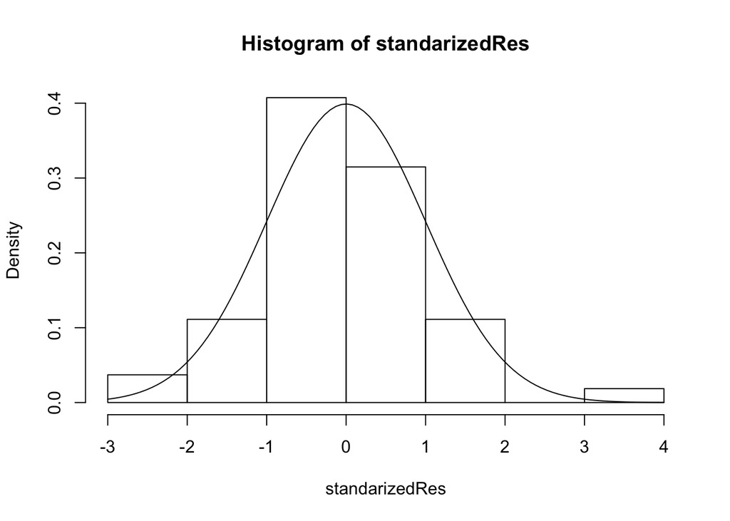

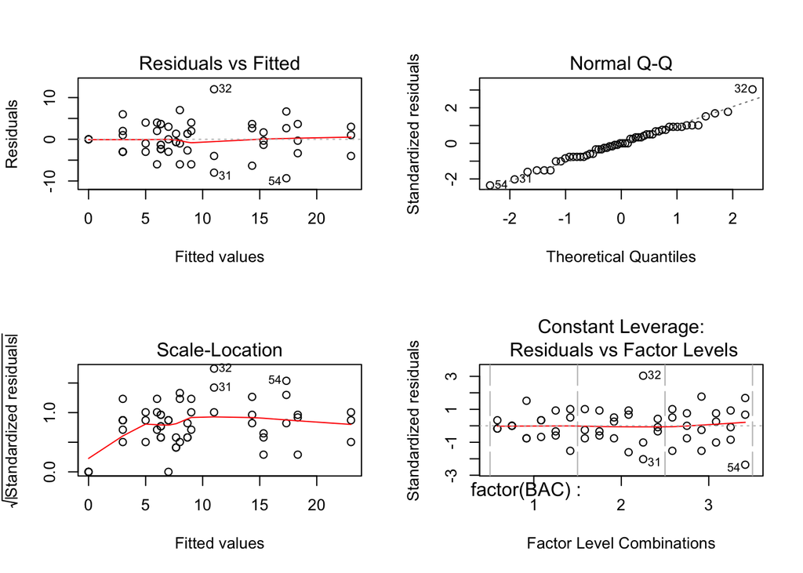

### Question 3 - Improving the model

```r
model_2 <- lm(ROT~factor(BAC)+factor(TEMP)+factor(OXYGEN)+factor(BAC):factor(TEMP)+factor(BAC):factor(OXYGEN)+factor(TEMP):factor(OXYGEN), data = potatoes)
anova(model_2)
```

```
## Analysis of Variance Table
##
## Response: ROT
##                             Df Sum Sq Mean Sq F value    Pr(>F)
## factor(BAC)                  2 651.81  325.91 14.0972 2.324e-05 ***
## factor(TEMP)                 1 848.07  848.07 36.6838 3.934e-07 ***
## factor(OXYGEN)               2  97.81   48.91  2.1155   0.13386
## factor(BAC):factor(TEMP)     2 152.93   76.46  3.3074   0.04685 *
## factor(BAC):factor(OXYGEN)   4  30.07    7.52  0.3252   0.85939
## factor(TEMP):factor(OXYGEN)  2   1.59    0.80  0.0344   0.96617
## Residuals                   40 924.74   23.12
## ---
## Signif. codes:  0 '***' 0.001 '**' 0.01 '*' 0.05 '.' 0.1 ' ' 1
```

```r
model_3 <- lm(ROT~factor(BAC)+factor(TEMP)+factor(OXYGEN)+factor(BAC):factor(TEMP), data = potatoes)
anova(model_3)
```

```
## Analysis of Variance Table
##
## Response: ROT
##                          Df Sum Sq Mean Sq F value    Pr(>F)
## factor(BAC)               2 651.81  325.91 15.6751 6.439e-06 ***
## factor(TEMP)              1 848.07  848.07 40.7895 7.606e-08 ***
## factor(OXYGEN)            2  97.81   48.91  2.3523   0.10650
## factor(BAC):factor(TEMP)  2 152.93   76.46  3.6776   0.03299 *
## Residuals                46 956.41   20.79
## ---
## Signif. codes:  0 '***' 0.001 '**' 0.01 '*' 0.05 '.' 0.1 ' ' 1
```

```r
model_4 <- lm(ROT~factor(BAC)+factor(TEMP)+factor(OXYGEN), data = potatoes)
anova(model_4)
```

```
## Analysis of Variance Table
##
## Response: ROT
##                Df  Sum Sq Mean Sq F value    Pr(>F)
## factor(BAC)     2  651.81  325.91 14.1018 1.522e-05 ***
## factor(TEMP)    1  848.07  848.07 36.6955 2.047e-07 ***
## factor(OXYGEN)  2   97.81   48.91  2.1162    0.1316
## Residuals      48 1109.33   23.11
## ---
## Signif. codes:  0 '***' 0.001 '**' 0.01 '*' 0.05 '.' 0.1 ' ' 1
```

### Question 4 - Which model is better?

```r
anova(model_1, model_2)
```

```
## Analysis of Variance Table
##
## Model 1: ROT ~ factor(BAC) * factor(TEMP) * factor(OXYGEN)
## Model 2: ROT ~ factor(BAC) + factor(TEMP) + factor(OXYGEN) + factor(BAC):factor(TEMP) +
##     factor(BAC):factor(OXYGEN) + factor(TEMP):factor(OXYGEN)
##   Res.Df    RSS Df Sum of Sq      F Pr(>F)
## 1     36 843.33
## 2     40 924.74 -4   -81.407 0.8688 0.4921
```

```r
anova(model_2, model_3)
```

```
## Analysis of Variance Table
##
## Model 1: ROT ~ factor(BAC) + factor(TEMP) + factor(OXYGEN) + factor(BAC):factor(TEMP) +
##     factor(BAC):factor(OXYGEN) + factor(TEMP):factor(OXYGEN)
## Model 2: ROT ~ factor(BAC) + factor(TEMP) + factor(OXYGEN) + factor(BAC):factor(TEMP)
##   Res.Df    RSS Df Sum of Sq      F Pr(>F)
## 1     40 924.74
## 2     46 956.41 -6   -31.667 0.2283 0.9651
```

```r
anova(model_3, model_4)
```

```
## Analysis of Variance Table
##
## Model 1: ROT ~ factor(BAC) + factor(TEMP) + factor(OXYGEN) + factor(BAC):factor(TEMP)
## Model 2: ROT ~ factor(BAC) + factor(TEMP) + factor(OXYGEN)
##   Res.Df     RSS Df Sum of Sq      F  Pr(>F)
## 1     46  956.41
## 2     48 1109.33 -2   -152.93 3.6776 0.03299 *
## ---
## Signif. codes:  0 '***' 0.001 '**' 0.01 '*' 0.05 '.' 0.1 ' ' 1
```

## Part 2

### Question 5

Testing BAC as a continuous variable would improve the model because it would show more sensitivity to the bacteria in the potatoes and let us better analyze the differences in oxygen and temperature treatments.

### Question 6 - Analysis with BAC as continuous variable

```r
model_5 <-lm(ROT~factor(TEMP):factor(OXYGEN)+BAC+factor(TEMP)+BAC+factor(OXYGEN), data = potatoes)
anova(model_5)
```

```
## Analysis of Variance Table
##
## Response: ROT
##                             Df  Sum Sq Mean Sq F value    Pr(>F)
## BAC                          1  650.25  650.25 27.5503 3.609e-06 ***
## factor(TEMP)                 1  848.07  848.07 35.9319 2.745e-07 ***
## factor(OXYGEN)               2   97.81   48.91  2.0722    0.1373
## factor(TEMP):factor(OXYGEN)  2    1.59    0.80  0.0337    0.9668
## Residuals                   47 1109.31   23.60
## ---
## Signif. codes:  0 '***' 0.001 '**' 0.01 '*' 0.05 '.' 0.1 ' ' 1
```

```r
model_6 <-lm(ROT~factor(TEMP)+BAC+factor(OXYGEN), data = potatoes)
anova(model_6)
```

```
## Analysis of Variance Table
##
## Response: ROT
##                Df  Sum Sq Mean Sq F value    Pr(>F)
## factor(TEMP)    1  848.07  848.07 37.4072 1.550e-07 ***
## BAC             1  650.25  650.25 28.6815 2.262e-06 ***
## factor(OXYGEN)  2   97.81   48.91  2.1572    0.1265
## Residuals      49 1110.90   22.67
## ---
## Signif. codes:  0 '***' 0.001 '**' 0.01 '*' 0.05 '.' 0.1 ' ' 1
```

### Question 7 and 8

```r
anova(model_5, model_6)
```

```
## Analysis of Variance Table
##
## Model 1: ROT ~ factor(TEMP):factor(OXYGEN) + BAC + factor(TEMP) + BAC +
##     factor(OXYGEN)
## Model 2: ROT ~ factor(TEMP) + BAC + factor(OXYGEN)
##   Res.Df    RSS Df Sum of Sq      F Pr(>F)
## 1     47 1109.3
## 2     49 1110.9 -2   -1.5926 0.0337 0.9668
```

### Question 9

error I kept getting: “non-numeric argument to binary operator” I don’t understand why as the data is all numbers

### Question 11

```r
temp2 <- filter(potatoes, TEMP =='2')
model_7 <-lm(temp2$ROT~temp2$TEMP:factor(temp2$OXYGEN)+temp2$BAC+temp2$TEMP+temp2$BAC+factor(temp2$OXYGEN))
anova(model_7)
```

```
## Analysis of Variance Table
##
## Response: temp2$ROT
##                      Df Sum Sq Mean Sq F value    Pr(>F)
## temp2$BAC             1 709.39  709.39 26.8183 2.998e-05 ***
## factor(temp2$OXYGEN)  2  56.52   28.26  1.0683      0.36
## Residuals            23 608.39   26.45
## ---
## Signif. codes:  0 '***' 0.001 '**' 0.01 '*' 0.05 '.' 0.1 ' ' 1
```